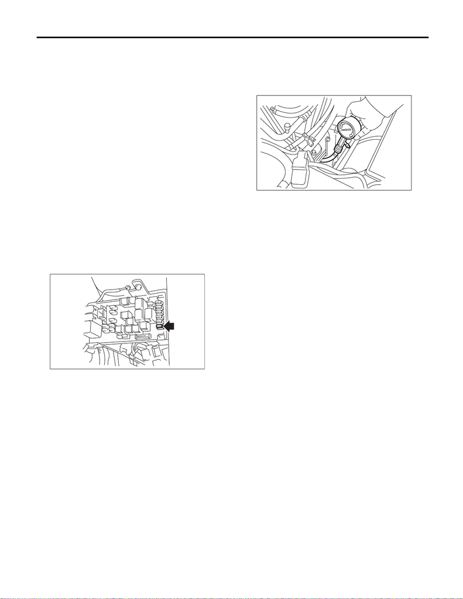

Compression

MECHANICAL

2. Compression

A: INSPECTION

CAUTION:

After warming-up, engine becomes very hot. Be

careful not to burn yourself during measure-

ment.

NOTE:

• Before checking the compression pressure, the

compression condition of each cylinder can be con-

firmed as a guide by using the compression mea-

surement mode in Subaru Select Monitor. <Ref. to

EN(STI)(diag)-60, OPERATION, System Opera-

tion Check Mode.>

• In the compression measurement mode, the

compression condition is judged by each cylinder

speed. The high speed cylinder has low compres-

sion pressure and low speed cylinder has high

compression pressure.

1) After warming-up the engine, turn the ignition

switch to OFF.

2) Make sure that the battery is fully charged.

3) Remove the fuse of fuel pump from main fuse

box.

4) Start the engine and run it until it stalls.

5) After the engine stalls, crank it for five more sec-

onds.

6) Turn the ignition switch to OFF.

7) Remove all spark plugs. <Ref. to IG(STI)-4, RE-

MOVAL, Spark Plug.>

8) Depress the accelerator pedal to full throttle.

9) Check the starter motor for satisfactory perfor-

mance and operation.

10) Install the compression gauge to the spark plug

hole.

NOTE:

When using a screw-in type compression gauge,

the screw should be less than 18 mm (0.71 in) long.

11) Crank the engine by starter motor and read the

value when the needle of the compression gauge

becomes stable.

NOTE:

• Perform at least two measurements per cylinder,

and make sure that the values are correct.

• If the compression pressure is out of standard,

check or adjust the pistons, valves and cylinders.

Compression (fully open throttle):

Standard

, 142 —

171 psi)

Difference between cylinders

, 7 psi), or less

12) After inspection, install the related parts in the

reverse order of removal.

FU-01122

ME-03009